# Analysis of the Effect of Immunizations on Life Expectancy

To showcase my data analysis and visualization skills, I decided to perform an analysis of the effect of immunizations on Life Expectancy over a period of time. The Life Expectancy data set published by the World Health Organization (WHO) focuses on data related to average life expectancy for 193 countries from the years 2000-2015. The dataset includes 21 predicting variables across the various categories, out of which, I will be focusing on Immunization.

I will be performing an analysis on the effect of Hepatitis B (HepB), Measles, Polio (Pol3), and Diphtheria tetanus toxoid and pertussis (DTP3) immunizations on the Life Expectancy of developing and developed countries throughout the years 2000-2015. Let's begin.

```python
#importing relevant libraries for the analysis
import pandas as pd
import seaborn as sns

#importing the data
df = pd.read_csv('Life Expectancy Dataset.csv')

#cleaning the data
df.columns = df.columns.str.strip()
```

### Effect of Hepatitis B (HepB) immunization coverage among 1-year-olds (%) on Life Expectancy of Developed and Developing countries

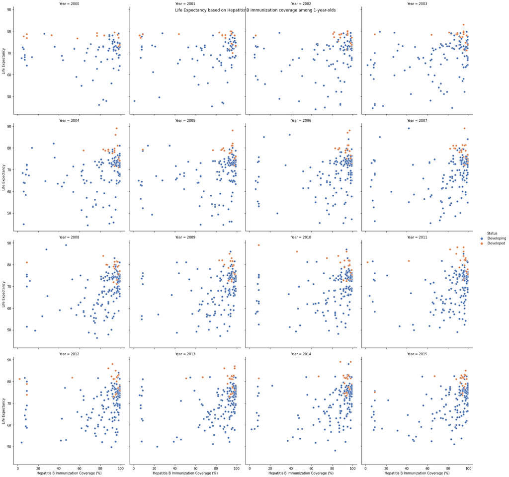

```python
#Life expectancy of Developed and Developing countries based on Hepatitis B (HepB) immunization coverage among 1-year-olds (%)
hepB = sns.relplot(x = 'Hepatitis B', y = 'Life expectancy', hue = 'Status', data = df, kind = 'scatter', col_wrap = 4, col = 'Year')
hepB.fig.suptitle('Life Expectancy based on Hepatitis B immunization coverage among 1-year-olds')
hepB.set(xlabel='Hepatitis B Immunization Coverage (%)', ylabel='Life Expectancy')
```

### Effect of Number of reported Measles cases per 1000 population on Life Expectancy of Developed and Developing countries

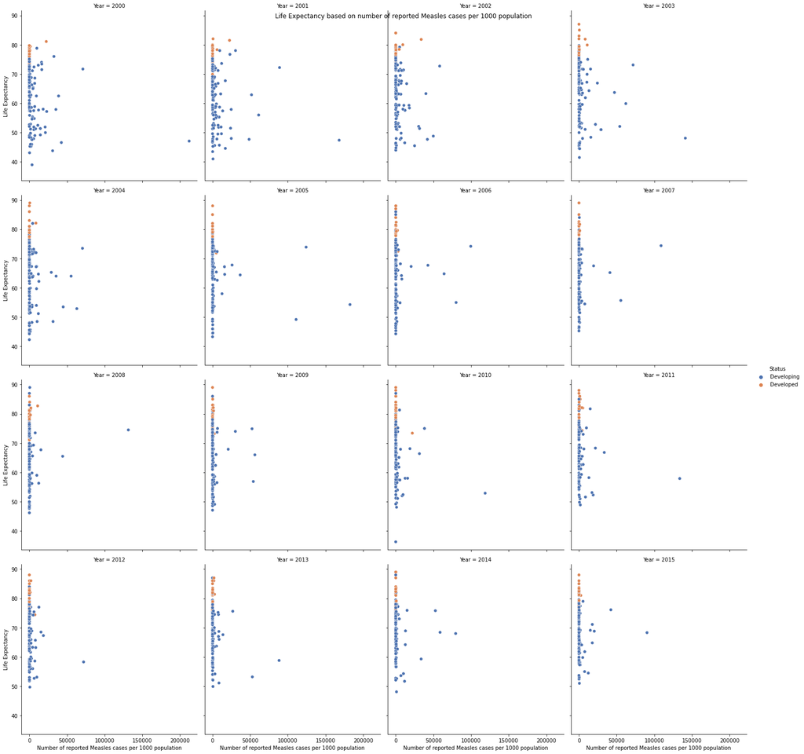

```python
#Life expectancy of Developed and Developing countries based on number of reported Measles cases per 1000 population
hepB = sns.relplot(x = 'Measles', y = 'Life expectancy', hue = 'Status', data = df, kind = 'scatter', col_wrap = 4, col = 'Year')
hepB.fig.suptitle('Life Expectancy based on number of reported Measles cases per 1000 population')
hepB.set(xlabel='Number of reported Measles cases per 1000 population', ylabel='Life Expectancy')
```

#### Interpretations:

Over the years, the number of reported measles cases have reduced significantly among the developing countries. We can clearly see the difference between the 2000 and 2015 plots. In developed countries, the number of reported measles cases have been low. As seen earlier, the life expectancies of developed countries is much higher than that of developing countries.

### Effect of Polio (Pol3) immunization coverage among 1-year-olds (%) on Life Expectancy of Developed and Developing countries

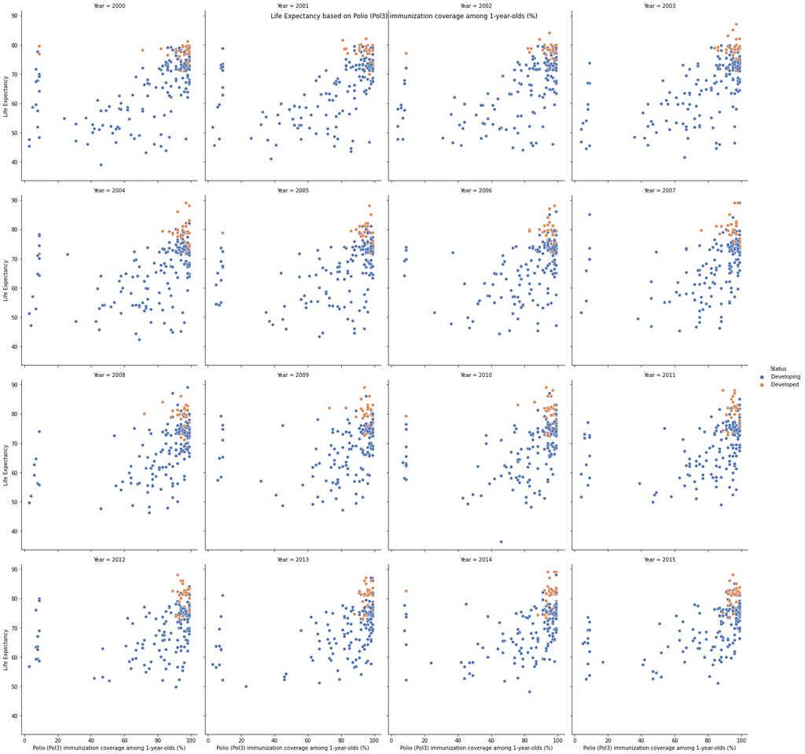

```python
#Life expectancy of Developed and Developing countries based on Polio (Pol3) immunization coverage among 1-year-olds (%)
hepB = sns.relplot(x = 'Polio', y = 'Life expectancy', hue = 'Status', data = df, kind = 'scatter', col_wrap = 4, col = 'Year')
hepB.fig.suptitle('Life Expectancy based on Polio (Pol3) immunization coverage among 1-year-olds (%)')
hepB.set(xlabel='Polio (Pol3) immunization coverage among 1-year-olds (%)', ylabel='Life Expectancy')
```

#### Interpretations:

Over the years, the Polio immunization coverage among 1-year olds has increased significantly among the developing countries. The points on the left of the plots (low polio immunization coverage) have progressively moved towards the right (high polio immunization coverage). In developed countries, the immunization coverage and life expectancy has been high since the beginning.

### Effect of Diphtheria tetanus toxoid and pertussis (DTP3) immunization coverage among 1-year-olds (%) on Life Expectancy of Developed and Developing countries

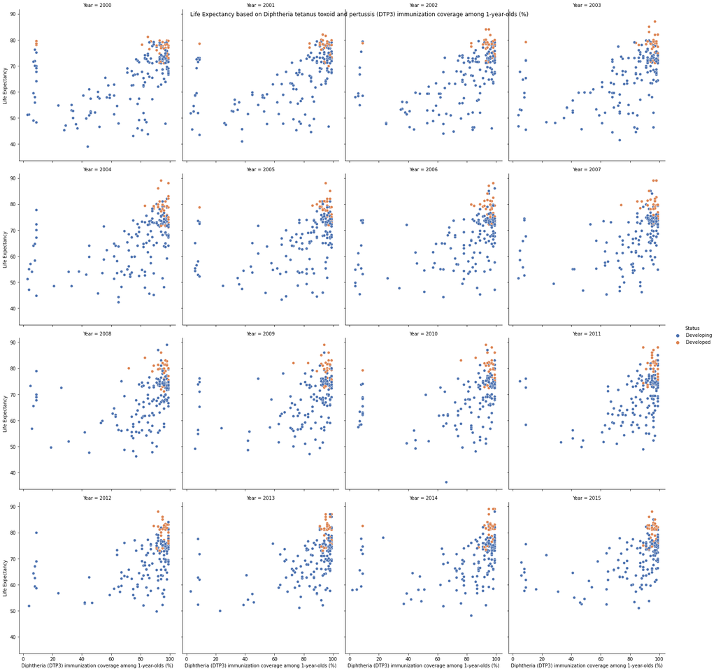

```python
#Life expectancy of Developed and Developing countries based on Diphtheria tetanus toxoid and pertussis (DTP3) immunization coverage among 1-year-olds (%)
hepB = sns.relplot(x = 'Diphtheria', y = 'Life expectancy', hue = 'Status', data = df, kind = 'scatter', col_wrap = 4, col = 'Year')
hepB.fig.suptitle('Life Expectancy based on Diphtheria tetanus toxoid and pertussis (DTP3) immunization coverage among 1-year-olds (%)')
hepB.set(xlabel='Diphtheria (DTP3) immunization coverage among 1-year-olds (%)', ylabel='Life Expectancy')
```

#### Interpretations:

We notice that the plot follows a trend similar to the other immunizations mentioned above. The points in the plot are crowded towards the right of the plot during the later years (signifying high diphtheria immunization coverage) in developing and developed countries. This has also seemed to affect the life expectancy as the points move further up along the y-axis (signifying higher life expectancy).

We can say that it is likely that the increase in immunizations among developing countries might be one of the many causes for an increase in life expectancies.